# ISLR - Chapter 07 - Lab

Saad M. Siddiqui

4/5/2022

In this lab we are going to anayse the `Wage` data set that was considered in examples throughout the chapter.

`Wage` is a data set of the `wage` earned by male employees of different age and education levels in the North Atlantic region of the US.

# Example 01 - Polynomial Regression and Step Functions

## Polynomial Models - Regression

```r
# Make a 4-degree global polynomial fit to the wage data
poly.fit <- lm(wage ~ poly(age, 4), data = Wage)
coef(summary(poly.fit))
```

```
##                 Estimate Std. Error    t value     Pr(>|t|)
## (Intercept)    111.70361  0.7287409 153.283015 0.000000e+00
## poly(age, 4)1  447.06785 39.9147851  11.200558 1.484604e-28
## poly(age, 4)2 -478.31581 39.9147851 -11.983424 2.355831e-32
## poly(age, 4)3  125.52169 39.9147851   3.144742 1.678622e-03
## poly(age, 4)4  -77.91118 39.9147851  -1.951938 5.103865e-02
```

The function `poly` actually returns a matrix whose columns are a basis of **orthogonal polynomials**: this means each column is a linear combination of the variables `age`, `age^2`, `age^3`, and `age^4`.

We can, however, also get the raw values of `age`, `age^2`, `age^3`, and `age^4` without the constraint that the polynomials are transformed to be orthogonal.

```r
poly.fit.raw <- lm(wage ~ poly(age, 4, raw = TRUE), data = Wage)
coef(summary(poly.fit.raw))
```

```
##                                Estimate   Std. Error   t value     Pr(>|t|)
## (Intercept)               -1.841542e+02 6.004038e+01 -3.067172 0.0021802539
## poly(age, 4, raw = TRUE)1  2.124552e+01 5.886748e+00  3.609042 0.0003123618
## poly(age, 4, raw = TRUE)2 -5.638593e-01 2.061083e-01 -2.735743 0.0062606446
## poly(age, 4, raw = TRUE)3  6.810688e-03 3.065931e-03  2.221409 0.0263977518
## poly(age, 4, raw = TRUE)4 -3.203830e-05 1.641359e-05 -1.951938 0.0510386498
```

The use of `raw = TRUE` only changes the coefficient estimates, but not the actual values that will be predicted by using these coefficients with this model.

There are also other ways of fitting the same model. Here, we create the polynomial basis functions of the previous code block on the fly using the wrapper function `I()` to ensure the `^` symbol is interpreted as a power, and not for the reserved usage in R formulae.

```r
# This is equivalent to the model initialised as poly.fit.raw
poly.fit.raw.01 <- lm(wage ~ age + I(age^2) + I(age^3) + I(age^4), data = Wage)
coef(poly.fit.raw.01)
```

```
##   (Intercept)           age      I(age^2)      I(age^3)      I(age^4)
## -1.841542e+02  2.124552e+01 -5.638593e-01  6.810688e-03 -3.203830e-05
```

Can also use the `cbind` function.

```r
poly.fit.raw.02 <- lm(wage ~ cbind(age, age^2, age^3, age^4), data = Wage)
coef(poly.fit.raw.02)
```

```
##                        (Intercept) cbind(age, age^2, age^3, age^4)age
##                      -1.841542e+02                       2.124552e+01
##    cbind(age, age^2, age^3, age^4)    cbind(age, age^2, age^3, age^4)
##                      -5.638593e-01                       6.810688e-03
##    cbind(age, age^2, age^3, age^4)
##                      -3.203830e-05
```

## Predictions - Regression

We now create a grid of values for `age` at which we want predictions, and then call the generic `predict` function to generate predictions with standard errors.

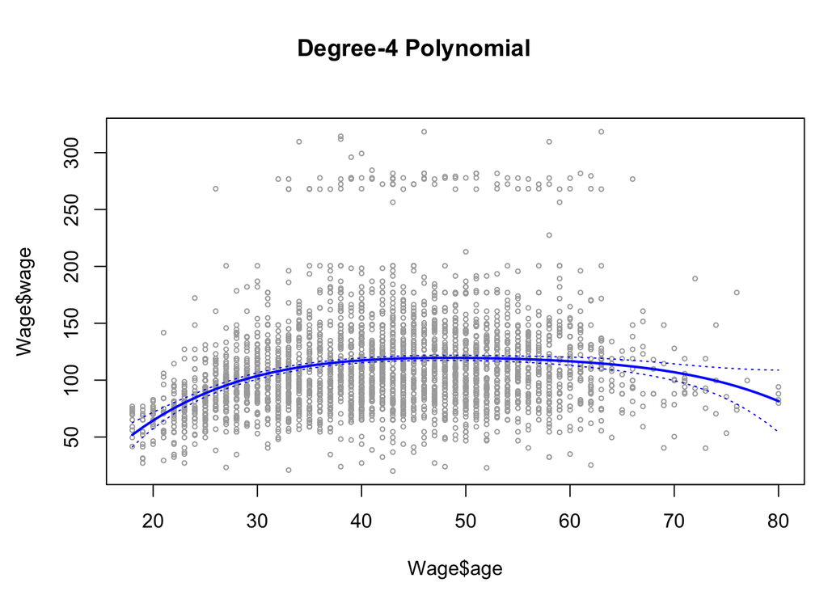

```r
# Get the range (min, max) of all age values in the dataset
age.lims <- range(Wage$age)
age.grid <- seq(from = age.lims[1], to = age.lims[2])

# Make predictions for a grid of values within this range
poly.fit.preds <- predict(poly.fit, newdata = list(age = age.grid), se = TRUE)

# Generate upper and lower 2-standard error bounds at each data point
poly.fit.se.bands <- cbind(
  poly.fit.preds$fit + 2 * poly.fit.preds$se.fit,
  poly.fit.preds$fit - 2 * poly.fit.preds$se.fit
)

# Plot the data and add the fit from the degree-4 polynomial
par(mfrow = c(1, 1), mar = c(4.5, 4.5, 1, 1), oma = c(0, 0, 4, 0)) # Specify margins
plot(Wage$age, Wage$wage, xlim = age.lims, cex = .5, col = 'darkgrey')

# Title will span both subplots
title('Degree-4 Polynomial', outer = T)

# Plot the predictions as well as upper and lower bounds for each point
lines(age.grid, poly.fit.preds$fit, lwd = 2, col = 'blue')
lines(age.grid, poly.fit.se.bands[, 1], lwd = 1, col = 'blue', lty = 3)
lines(age.grid, poly.fit.se.bands[, 2], lwd = 1, col = 'blue', lty = 3)
```

```r
poly.fit.raw.preds <- predict(poly.fit.raw, newdata = list(age = age.grid), se = TRUE)
max(abs(poly.fit.raw.preds$fit - poly.fit.preds$fit))
```

```
## [1] 7.81597e-11
```

## Identifying Polynomial Degree through ANOVA

In performing polynomial regression, we need to decide on the degree of the polynomial. One way of doing this is to use a hypothesis test. Here, we fit different models from degree 1 to degree 5, and then use a hypothesis test to determine the simplest model which is sufficient to explain the relationship between `wage` and `age`.

The `anova` function performs an analysis of variance using an F-test to test the null hypothesis that model $\M_1$ is sufficient to explain the data against an alternative hypothesis that a more complicated model $\M_2$ is required.

```r
# Fit models
poly.fit.deg.01 <- lm(wage ~ age, data = Wage)
poly.fit.deg.02 <- lm(wage ~ poly(age, 2), data = Wage)
poly.fit.deg.03 <- lm(wage ~ poly(age, 3), data = Wage)
poly.fit.deg.04 <- lm(wage ~ poly(age, 4), data = Wage)
poly.fit.deg.05 <- lm(wage ~ poly(age, 5), data = Wage)

# Call the `anova` function
anova(poly.fit.deg.01, poly.fit.deg.02, poly.fit.deg.03, poly.fit.deg.04, poly.fit.deg.05)
```

```
## Analysis of Variance Table
##
## Model 1: wage ~ age
## Model 2: wage ~ poly(age, 2)
## Model 3: wage ~ poly(age, 3)
## Model 4: wage ~ poly(age, 4)
## Model 5: wage ~ poly(age, 5)
##   Res.Df     RSS Df Sum of Sq        F    Pr(>F)
## 1   2998 5022216
## 2   2997 4793430  1    228786 143.5931 < 2.2e-16 ***
## 3   2996 4777674  1     15756   9.8888  0.001679 **
## 4   2995 4771604  1      6070   3.8098  0.051046 .
## 5   2994 4770322  1      1283   0.8050  0.369682
## ---
## Signif. codes:  0 '***' 0.001 '**' 0.01 '*' 0.05 '.' 0.1 ' ' 1
```

We could also have obtained the same information with a `summary` command on the highest degree model.

```r
coef(summary(poly.fit.deg.05))
```

```
##                 Estimate Std. Error     t value     Pr(>|t|)
## (Intercept)    111.70361  0.7287647 153.2780243 0.000000e+00
## poly(age, 5)1  447.06785 39.9160847  11.2001930 1.491111e-28
## poly(age, 5)2 -478.31581 39.9160847 -11.9830341 2.367734e-32
## poly(age, 5)3  125.52169 39.9160847   3.1446392 1.679213e-03
## poly(age, 5)4  -77.91118 39.9160847  -1.9518743 5.104623e-02
## poly(age, 5)5  -35.81289 39.9160847  -0.8972045 3.696820e-01
```

The $p$-values are stil the same, and the square of the $t$-statistics is equal to the $F$-statistics from `anova`.

`anova` works regardless of orthogonality of the polynomial basis functions, and also works with models that have polynomial features along with other features.

```r
mix.fit.01 <- lm(wage ~ education + age, data = Wage)
mix.fit.02 <- lm(wage ~ education + poly(age, 2), data = Wage)
mix.fit.03 <- lm(wage ~ education + poly(age, 3), data = Wage)

anova(mix.fit.01, mix.fit.02, mix.fit.03)
```

```
## Analysis of Variance Table
##
## Model 1: wage ~ education + age
## Model 2: wage ~ education + poly(age, 2)
## Model 3: wage ~ education + poly(age, 3)
##   Res.Df     RSS Df Sum of Sq        F Pr(>F)
## 1   2994 3867992
## 2   2993 3725395  1    142597 114.6969 <2e-16 ***
## 3   2992 3719809  1      5587   4.4936 0.0341 *
## ---
## Signif. codes:  0 '***' 0.001 '**' 0.01 '*' 0.05 '.' 0.1 ' ' 1
```

Based on these $p$-values, we can reject `mix.fit.01` in favour of `mix.fit.02`, and `mix.fit.02` in favour of `mix.fit.03`, although we should still check the $p$-value for a more complex model for `mix.fit.03`.

## Polynomial Models - Classification

We now consider the taks of predicting whether an individual earns more than $250k per year using binary classification with a polynomial model.

```r
poly.class.fit <- glm(I(wage > 250) ~ poly(age, 4), data = Wage, family = 'binomial')
poly.class.preds.logit <- predict(poly.class.fit, newdata = list(age = age.grid), se = T)
```

Because the default prediction type for `predict` is `type = 'link'`, we get predictions for the logit, not the actual posterior probability. This means we are getting predictions of the form
$$log(\frac{Pr(Y = 1 | X)}{1 - Pr(Y = 1 | X)}) = X\beta$$

Whereas what we really want is predictions of the form
$$Pr(Y = 1 | X) = \frac{exp(X\beta)}{1 + exp(X\beta)}$$

We perform this transformation below.

```r
poly.class.preds <- exp(poly.class.preds.logit$fit) / (1 + exp(poly.class.preds.logit$fit))
poly.class.se.bands.logit <- cbind(
  poly.class.preds.logit$fit + 2 * poly.class.preds.logit$se.fit,
  poly.class.preds.logit$fit - 2 * poly.class.preds.logit$se.fit
)
poly.class.se.bands <- exp(poly.class.se.bands.logit) / (1 + exp(poly.class.se.bands.logit))
```

We could also have computed these directly using the `type = 'response'` option in the `predict` function. However, with this approach, the corresponding confidence intervals would not have been possible because the SEs would have resulted in negative probabilities.

```r
poly.class.preds.direct <- predict(poly.class.fit, newdata = list(age = age.grid),
                            type = 'response', se = TRUE)
mean((poly.class.preds - poly.class.preds.direct$fit)^2) # No difference
```

```
## [1] 0
```

We now generate the posterior probability plot for high income earners.

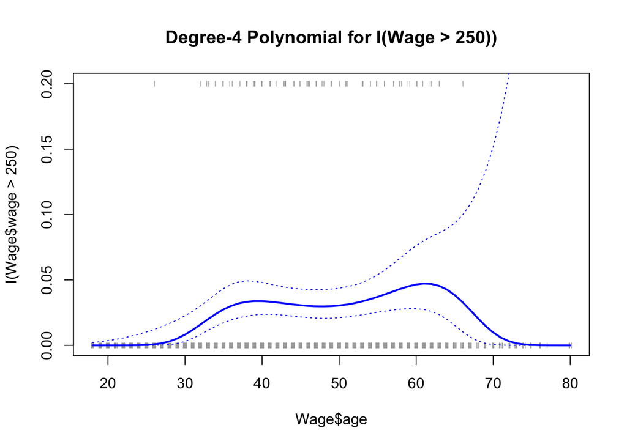

```r
plot(Wage$age, I(Wage$wage > 250), xlim = age.lims, type = 'n', ylim = c(0., .2))
points(jitter(Wage$age), I((Wage$wage > 250) / 5), cex  = 0.5, pch = 'l', col = 'darkgrey')
lines(age.grid, poly.class.preds, lwd =2 , col = 'blue')
matlines(age.grid, poly.class.se.bands, lwd = 1, col = 'blue', lty = 3)
title('Degree-4 Polynomial for I(Wage > 250))')
```

`age` values for wages above 250k are drawn at the top axis, while age values for wages below 250k are drawn on the bottom axis. `jitter` ensures observations with the same `age` values don’t overlap. This is often called a **rug plot**.

## Step Function

We use the `cut` command to generate buckets for the step function.

```r
table(cut(Wage$age, 4))    # Cut the `age` variable into 4 intervals
```

```
##
## (17.9,33.5]   (33.5,49]   (49,64.5] (64.5,80.1]
##         750        1399         779          72
```

```r
# Fit a linear model using the same categories as dummy variables
step.fit <- lm(wage ~ cut(age, 4), data = Wage)
coef(summary(step.fit))
```

```
##                         Estimate Std. Error   t value     Pr(>|t|)
## (Intercept)            94.158392   1.476069 63.789970 0.000000e+00
## cut(age, 4)(33.5,49]   24.053491   1.829431 13.148074 1.982315e-38
## cut(age, 4)(49,64.5]   23.664559   2.067958 11.443444 1.040750e-29
## cut(age, 4)(64.5,80.1]  7.640592   4.987424  1.531972 1.256350e-01
```

`cut` automatically chose breakpoints for us. We could have specified them ourselves using the `breaks` argument.

Because the category `age < 33.5` is left out, the intercept coefficient of $94,160 can be interpreted as the average salary for those under 33.5 years of age. Other coefficients can be interpreted as offsets ot this base salary for each age interval.

# Example 02 - Splines

## Regression Spline

Regression splines can be constructed by constructing an appropriate matrix of basis functions according to a specified set of knots. We do this with the `bs` command.

By default, `bs` will fit a regression spline of `degree = 3`.

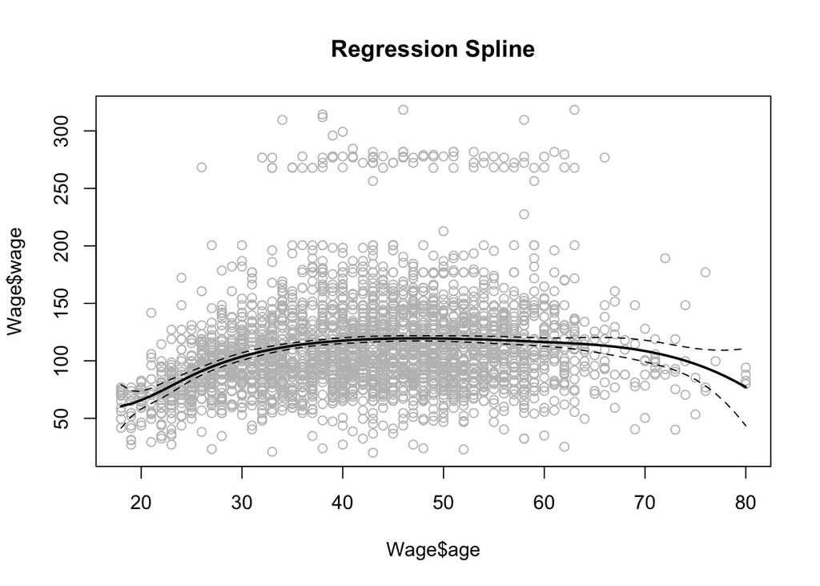

```r
reg.spline.01.fit <- lm(wage ~ bs(age, knots = c(25, 40, 60)), data = Wage)
reg.spline.01.pred <- predict(reg.spline.01.fit, newdata = list(age = age.grid), se = T)
plot(Wage$age, Wage$wage, col = 'gray')

title("Regression Spline")
lines(age.grid, reg.spline.01.pred$fit, lwd = 2)
lines(age.grid, reg.spline.01.pred$fit + 2 * reg.spline.01.pred$se.fit, lty = 'dashed')
lines(age.grid, reg.spline.01.pred$fit - 2 * reg.spline.01.pred$se.fit, lty = 'dashed')
```

Here, we have prespecified knots at ages 25, 40, and 60. This has produced a spline with six basis functions (a spline with $K$ knots has $K + 4$ degrees of freedom. Here, $K = 3$, so 7 degrees of freedom used up by the intercept + 6 basis functions.

We could use the `df` option to produce a spline with knots at uniform quantiles of the data.

```r
dim(bs(Wage$age, knots = c(25, 40, 60))) # Our original spline
```

```
## [1] 3000    6
```

```r
dim(bs(Wage$age, df = 6))                # Identical to previous, even though we specify DoF
```

```
## [1] 3000    6
```

```r
attr(bs(Wage$age, df = 6), 'knots')      # With 6 DoF, at what points does R chose knots?
```

```
##   25%   50%   75%
## 33.75 42.00 51.00
```

## Natural Spline

In orer to fit a natural spline (a spline where fit is constrained to be linear at $X$ below lowest knot and above highest knot), we use the `ns()` function. Here, we fit a natural spline with four degrees of freedom.

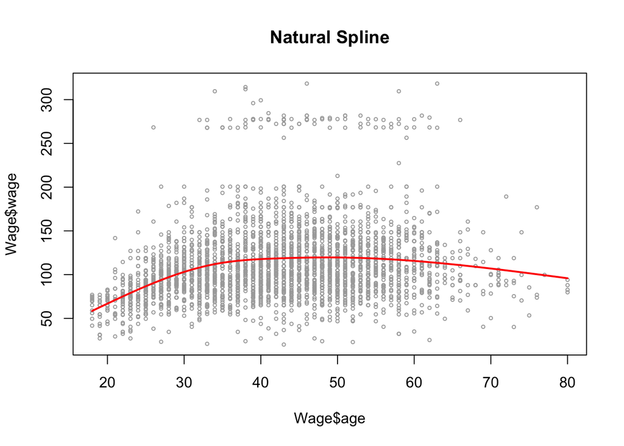

```r
reg.spline.02.fit <- lm(wage ~ ns(age, df = 4), data = Wage)
reg.spline.02.pred <- predict(reg.spline.02.fit, newdata = list(age = age.grid), se = T)

plot(Wage$age, Wage$wage, xlim = age.lims, cex = .5, col = 'darkgrey')
title("Natural Spline")
lines(age.grid, reg.spline.02.pred$fit, col = 'red', lwd = 2)
```

As with the `bs` function, we could have also specified the knots directly using the `knots` argument.

## Smoothing Spline

In order to fit a smoothing spline, we use the `smooth.spline` function.

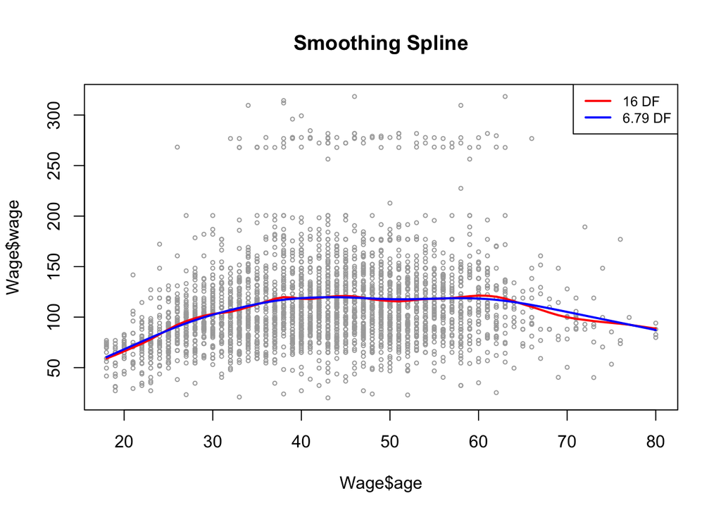

```r
plot(Wage$age, Wage$wage, xlim = age.lims, cex = .5, col = 'darkgrey')
title("Smoothing Spline")
smooth.spline.01.fit <- smooth.spline(Wage$age, Wage$wage, df = 16)   # Specify DoF
smooth.spline.02.fit <- smooth.spline(Wage$age, Wage$wage, cv = TRUE)  # Use LOOCV for DoF
lines(smooth.spline.01.fit, col = 'red', lwd = 2)
lines(smooth.spline.02.fit, col = 'blue', lwd = 2)
legend(
  'topright',
  legend = c(paste0(round(smooth.spline.01.fit$df, 2), " DF"),
             paste0(round(smooth.spline.02.fit$df, 2), " DF")),
  col = c("red", "blue"),
  lty = 1,
  lwd = 2 ,
  cex = .8
)
```

In the red curve, we specified the degrees of freedom. In the second case, we let LOOCV select the appropriate smoothing parameter $\lambda$ which led to 6.8 DoF.

## Local Regression

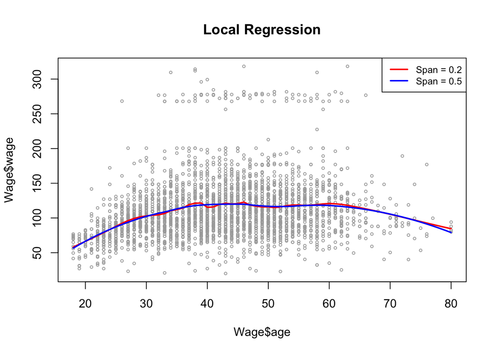

```r
plot(Wage$age, Wage$wage, xlim = age.lims, cex = 0.5, col = 'darkgrey')
title("Local Regression")

local.reg.01.fit <- loess(wage ~ age, data = Wage, span = 0.2)
local.reg.02.fit <- loess(wage ~ age, data = Wage, span = 0.5)

lines(age.grid, predict(local.reg.01.fit, data.frame(age = age.grid)), col = 'red', lwd = 2)
lines(age.grid, predict(local.reg.02.fit, data.frame(age = age.grid)), col = 'blue', lwd = 2)

legend(
  'topright',
  legend = c('Span = 0.2', 'Span = 0.5'),
  col = c('red', 'blue'),
  lty = 1,
  lwd = 2,
  cex = .8
)
```

A span of 0.2 and 0.5 means we are using a neighborhood that contains 20% and 50% of the observations. The larger the span, the smoother the fit.

# Example 03 - GAMs

We now fit a generative additive model (GAM) to predict `wage` using natural spline function of the `year` and `age`, and treat `education` as a qualitative predictor.

This is, essentially, still a linear model but with a choice of different basis functions for each variable. So we can use the `lm` function.

```r
gam.01.fit <- lm(wage ~ ns(year, 4) + ns(age, 5) + education, data = Wage)
```

We now use the `gam::s()` function specify smoothing splines with different degrees of freedom for each of the quantitative variables. We also use the `gam` function instead of the `lm` function.

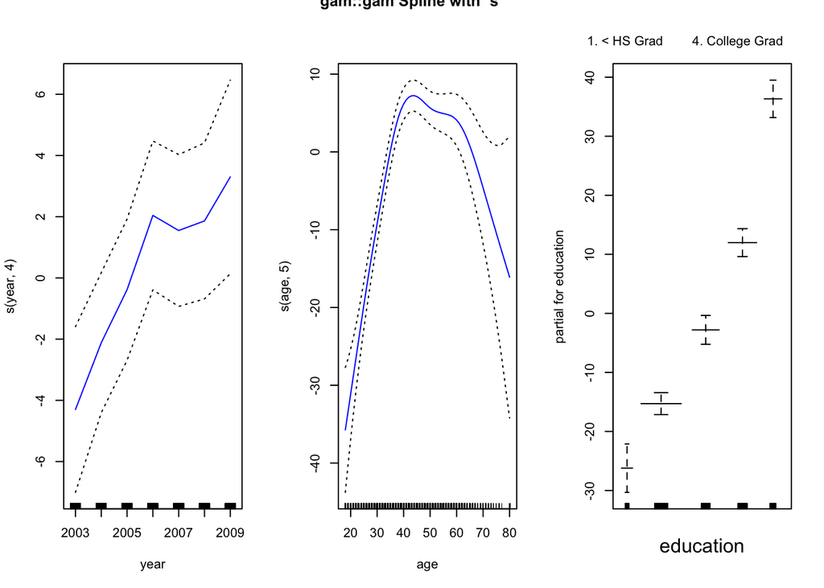

```r
gam.02.fit <- gam(wage ~ s(year, 4) + s(age, 5) + education, data = Wage)
par(mfrow = c(1, 3))
plot(gam.02.fit, se = TRUE, col = 'blue')   # Automatically recognized as GAM plot
title("gam::gam Spline with `s`", outer = TRUE)
```

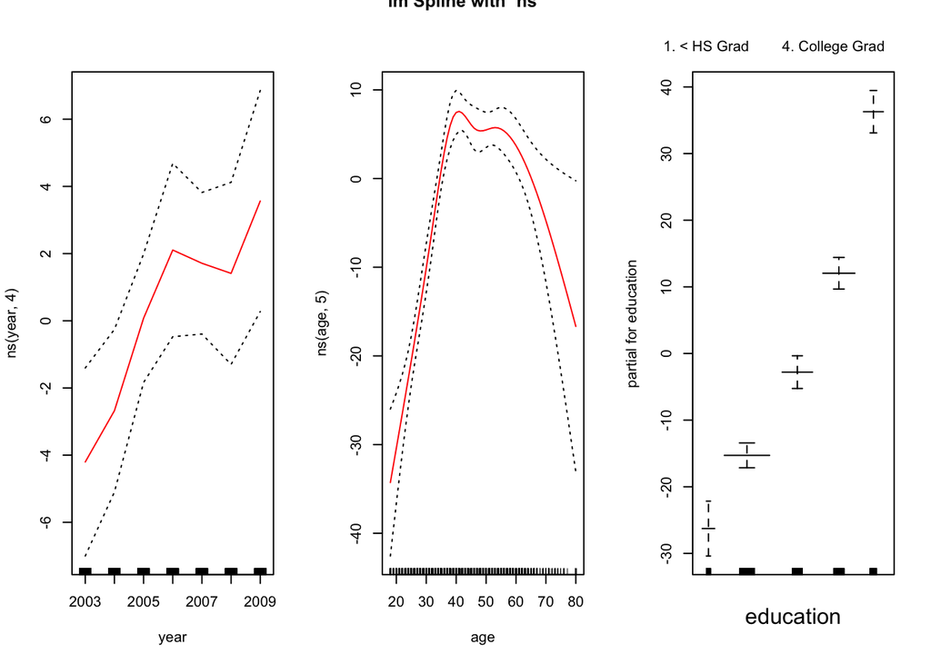

```r
# Can also plot lm objects using the plot.Gam() function
plot.Gam(gam.01.fit, se = TRUE, col = 'red')
title("lm Spline with `ns`", outer = TRUE)
```

## ANOVA with GAM

In these plots, `year` looks like it might be linearly correlated with `Wage`. We can perform a series of ANOVA tests in order to determine which of the three models is best

1. $\mathcal{M_1}$ - a GAM that excludes `year`
2. $\mathcal{M_2}$ - a GAM that uses a linear function of `year`
3. $\matchal{M_3}$- a GAM that uses a spline function of `year`

```r
# Fit models
gam.m01 <- gam(wage ~ s(age, 5) + education, data = Wage)
gam.m02 <- gam(wage ~ s(age, 5) + education + year, data = Wage)
gam.m03 <- gam(wage ~ s(age, 5) + education + s(year, 4), data = Wage)

# Carry out ANOVA
anova(gam.m01, gam.m02, gam.m03, test = "F")
```

```
## Analysis of Deviance Table
##
## Model 1: wage ~ s(age, 5) + education
## Model 2: wage ~ s(age, 5) + education + year
## Model 3: wage ~ s(age, 5) + education + s(year, 4)
##   Resid. Df Resid. Dev Df Deviance       F    Pr(>F)
## 1      2990    3711731
## 2      2989    3693842  1  17889.2 14.4771 0.0001447 ***
## 3      2986    3689770  3   4071.1  1.0982 0.3485661
## ---
## Signif. codes:  0 '***' 0.001 '**' 0.01 '*' 0.05 '.' 0.1 ' ' 1
```

To reiterate, the $p$-value of 0.0001447 means there is compelling evidence against the null hypothesis that we can use a linear model to assess relationship between predictor and response in favour of $\mathcal{M_2}$.

Likewise, a $p$-value of 0.348 for row 3 means there is no evidence that we should reject M02 in favour of $\mathcal{M_3}$ for a better fit between predictors and responses.

So $\mathcal{M_2}$ is the best model to use in this case.

```r
summary(gam.m03)
```

```
##
## Call: gam(formula = wage ~ s(age, 5) + education + s(year, 4), data = Wage)
## Deviance Residuals:
##     Min      1Q  Median      3Q     Max
## -119.43  -19.70   -3.33   14.17  213.48
##
## (Dispersion Parameter for gaussian family taken to be 1235.69)
##
##     Null Deviance: 5222086 on 2999 degrees of freedom
## Residual Deviance: 3689770 on 2986 degrees of freedom
## AIC: 29887.75
##
## Number of Local Scoring Iterations: NA
##
## Anova for Parametric Effects
##              Df  Sum Sq Mean Sq F value    Pr(>F)
## s(age, 5)     1  200684  200684 162.406 < 2.2e-16 ***
## education     4 1073944  268486 217.276 < 2.2e-16 ***
## s(year, 4)    1   17598   17598  14.242 0.0001639 ***
## Residuals  2986 3689770    1236
## ---
## Signif. codes:  0 '***' 0.001 '**' 0.01 '*' 0.05 '.' 0.1 ' ' 1
##
## Anova for Nonparametric Effects
##             Npar Df Npar F  Pr(F)
## (Intercept)
## s(age, 5)         4 32.380 <2e-16 ***
## education
## s(year, 4)        3  1.086 0.3537
## ---
## Signif. codes:  0 '***' 0.001 '**' 0.01 '*' 0.05 '.' 0.1 ' ' 1
```

## Prediction with GAM

```r
gam.m02.preds <- predict(gam.02.fit, newdata = Wage)
```

## Local Regression with GAM

Here, we fit a two-term model in which the first term is an interaction between `year` and `age`, fit by a local regression surface.

```r
gam.lo.i <- gam(wage ~ lo(year, age, span = 0.5) + education, data = Wage)
```

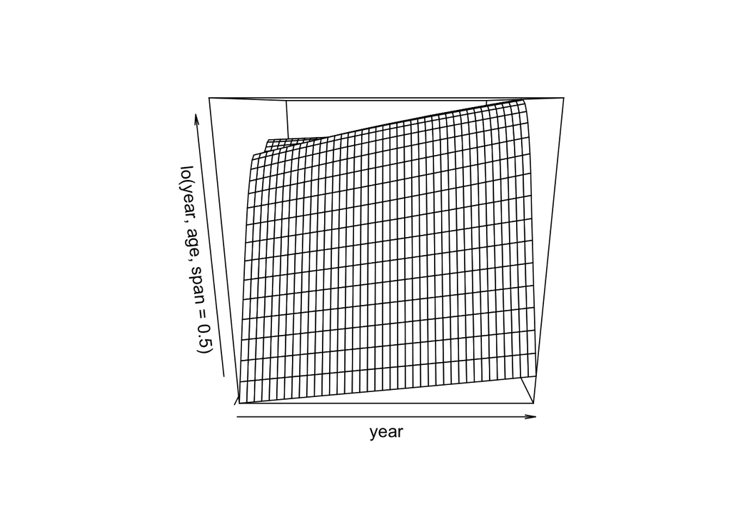

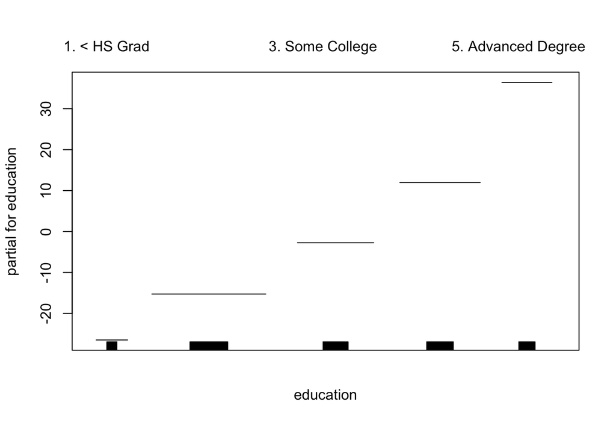

```r
plot(gam.lo.i)
```

## Logistic Regression with GAM

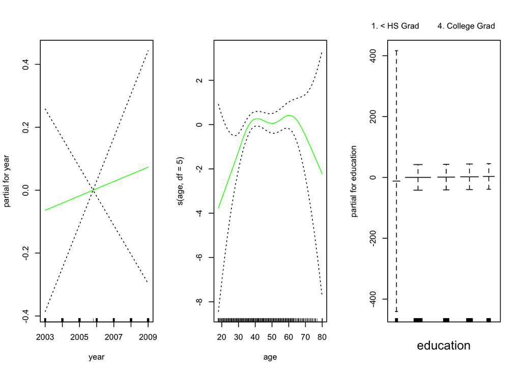

```r
gam.lr <- gam(
  I(wage > 250) ~ year + s(age, df = 5) + education,
  family = binomial,
  data = Wage
)

par(mfrow = c(1, 3))
plot(gam.lr, se = T, col = 'green')
```

```r
# No high earners in the < HS category
table(Wage$education, I(Wage$wage > 250))
```

```
##
##                      FALSE TRUE
##   1. < HS Grad         268    0
##   2. HS Grad           966    5
##   3. Some College      643    7
##   4. College Grad      663   22
##   5. Advanced Degree   381   45
```

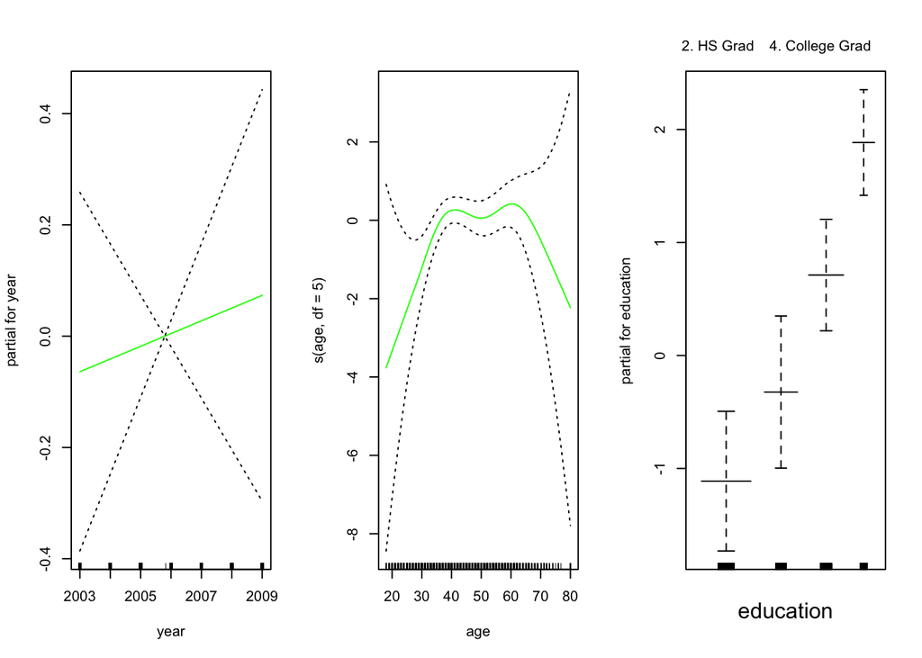

```r
# So fit a logistic regression GAM using all but this category
gam.lr.s <- gam(
  I(wage > 250) ~ year + s(age, df = 5) + education,
  family = binomial,
  data = Wage,
  subset = (education != '1. < HS Grad')
)

plot(gam.lr.s, se = T, col = 'green')
```